# GLM-Binomial

Livio Finos

### Disclaimer

This material is largely taken from the one developed by Dr Filippo Gambarota, who kindly allowed me to take and reduce at my will. The original didactic material can be found here https://github.com/stat-teaching/GLMphd

# Introduction and motivation

## Example: Passing the exam

We want to measure the impact of **watching tv-shows** on the probability of **passing the statistics exam**.

- `exam`: **passing the exam** (1 = “passed”, 0 = “failed”)
- `tv_shows`: **watching tv-shows regularly** (1 = “yes”, 0 = “no”)

| tv_shows | exam |
| --- | --- |
| 1 | 1 |
| 1 | 1 |
| 1 | 1 |
| 1 | 0 |
| ... | ... |
| 0 | 0 |
| 0 | 0 |
| 0 | 1 |
| 0 | 0 |

We can create the **contingency table**

```r
xtabs(~exam + tv_shows, data = dat) |>
    addmargins()
```

```
##      tv_shows
## exam    0   1 Sum
##   0    34  23  57
##   1    16  27  43
##   Sum  50  50 100
```

Each cell probability $p_{ij}$ is computed as $p_{ij}/n$

```r
(xtabs(~exam + tv_shows, data = dat)/n) |>
    addmargins()
```

```
##      tv_shows
## exam     0    1  Sum
##   0   0.34 0.23 0.57
##   1   0.16 0.27 0.43
##   Sum 0.50 0.50 1.00
```

Conditional probabilities:

```r
(xtabs(~exam + tv_shows, data = dat)) |>
    prop.table(1)
```

```
##     tv_shows
## exam         0         1
##    0 0.5964912 0.4035088
##    1 0.3720930 0.6279070
```

### Example: Passing the exam - Odds

The most common way to analyze a 2x2 contingency table is using the **odds ratio** (OR). Firsly let’s define *the odds of success* as:

$$\begin{align*}
odds = \frac{p}{1 - p} \\
p = \frac{odds}{odds + 1}
\end{align*}$$

- the **odds** are non-negative, ranging between 0 and $+\infty$
- an **odds** of e.g. 3 means that we expect 3 *success* for each *failure*

For the `exam` example:

```r
odds <- function(p) p / (1 - p)
p11 <- mean(with(dat, exam[tv_shows == 1])) # passing exam | tv_shows
p11
```

```
## [1] 0.54
```

```r
odds(p11)
```

```
## [1] 1.173913
```

### Example: Passing the exam - Odds Ratio

The OR is a ratio of odds:

$$OR = \frac{\frac{p_1}{1 - p_1}}{\frac{p_2}{1 - p_2}}$$

- OR ranges between 0 and $+\infty$. When $OR = 1$ the odds for the two conditions are equal
- An e.g. $OR = 3$ means that being in the condition at the numerator increase 3 times the odds of success

```r
odds_ratio <- function(p1, p2) odds(p1) / odds(p2)
p11 <- mean(with(dat, exam[tv_shows == 1])) # passing exam | tv_shows
p10 <- mean(with(dat, exam[tv_shows == 0])) # passing exam | not tv_shows
p11
```

```
## [1] 0.54
```

```r
p10
```

```
## [1] 0.32
```

```r
odds(p11)
```

```
## [1] 1.173913
```

```r
log(odds(p11))
```

```
## [1] 0.1603427
```

```r
odds(p10)
```

```
## [1] 0.4705882
```

```r
log(odds(p10))
```

```
## [1] -0.7537718
```

```r
odds_ratio(p11, p10)
```

```
## [1] 2.494565
```

## Why using Odds and Odds Ratios?

The odds have an interesting property when taking the logarithm. We can express a probability $p$ using a scale ranging $[-\infty, +\infty]$

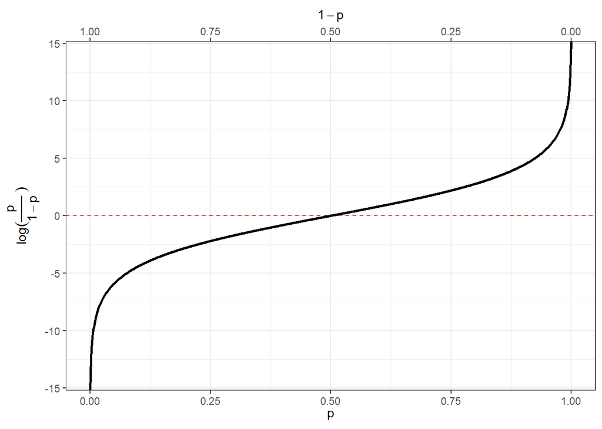

## Another example, **Teddy Child**

We considered a Study conducted by the University of Padova (TEDDY Child Study, 2020)[^1]. Within the study, researchers asked the participants (mothers of a young child) about the presence of post-partum depression and measured the parental stress using the PSI-Parenting Stress Index.

| ID | Parental_stress | Depression_pp |
| --- | --- | --- |
| 1 | 75 | No |
| 2 | 51 | No |
| 3 | 76 | No |
| 4 | 88 | No |
| ... | ... | ... |
| 376 | 67 | No |
| 377 | 71 | No |
| 378 | 63 | No |
| 379 | 70 | No |

We want to see if the parental stress increase the probability of having post-partum depression:

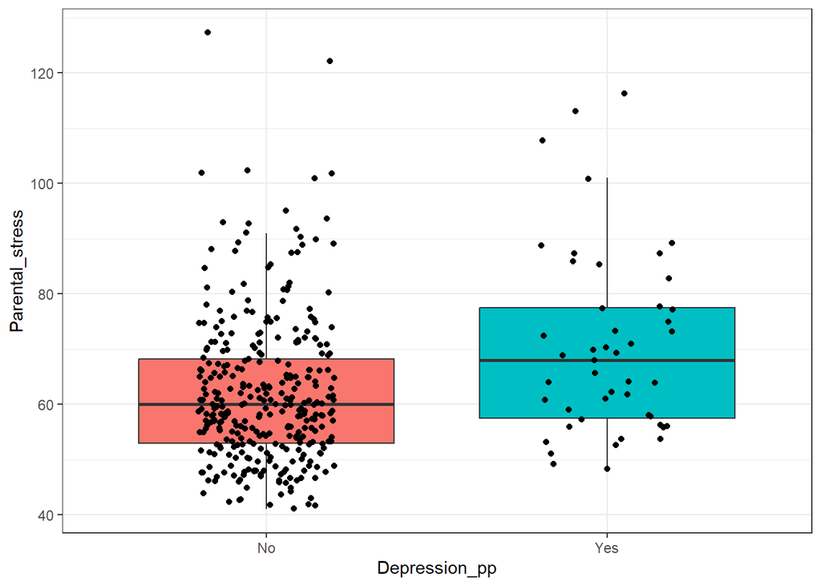

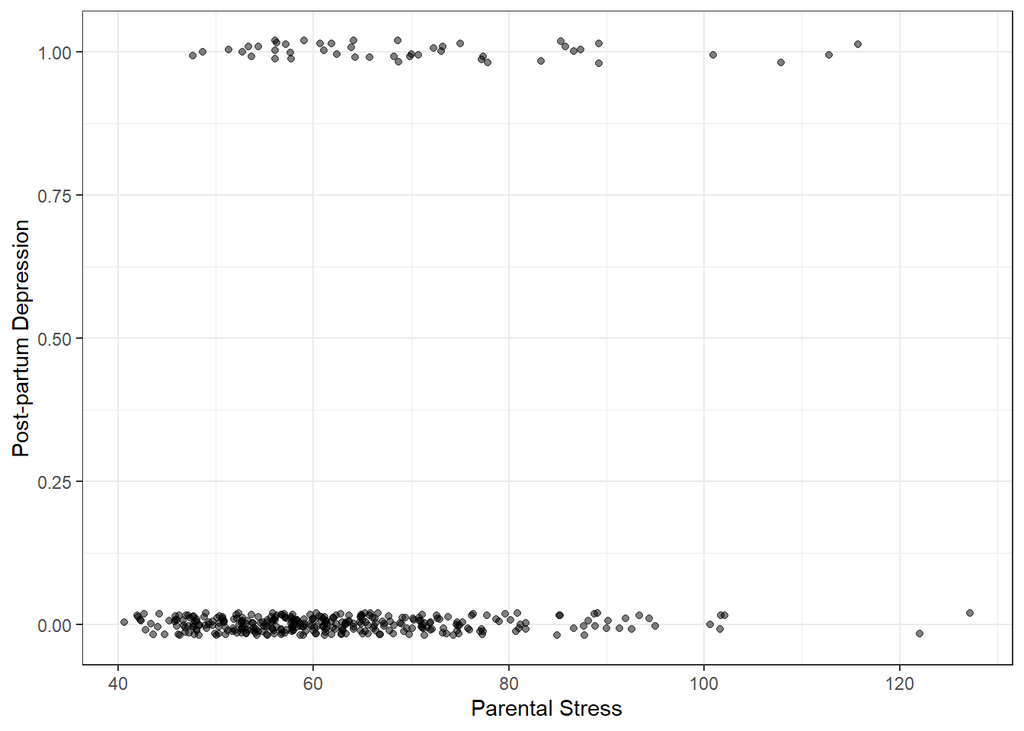

Let’s start by fitting a linear model `Depression_pp ~ Parental_stress`. We consider “Yes” as 1 and “No” as 0.

```r
fit_lm <- lm(Depression_pp01 ~ Parental_stress, data = teddy)
summary(fit_lm)
```

```
##
## Call:
## lm(formula = Depression_pp01 ~ Parental_stress, data = teddy)
##
## Residuals:
##      Min       1Q   Median       3Q      Max
## -0.42473 -0.13768 -0.10003 -0.05768  0.94702
##
## Coefficients:
##                  Estimate Std. Error t value Pr(>|t|)
## (Intercept)     -0.172900   0.077561  -2.229 0.026389 *
## Parental_stress  0.004706   0.001201   3.919 0.000105 ***
## ---
## Signif. codes:  0 '***' 0.001 '**' 0.01 '*' 0.05 '.' 0.1 ' ' 1
##
## Residual standard error: 0.3239 on 377 degrees of freedom
## Multiple R-squared:  0.03915,    Adjusted R-squared:  0.0366
## F-statistic: 15.36 on 1 and 377 DF,  p-value: 0.0001054
```

Let’s add the fitted line to our plot:

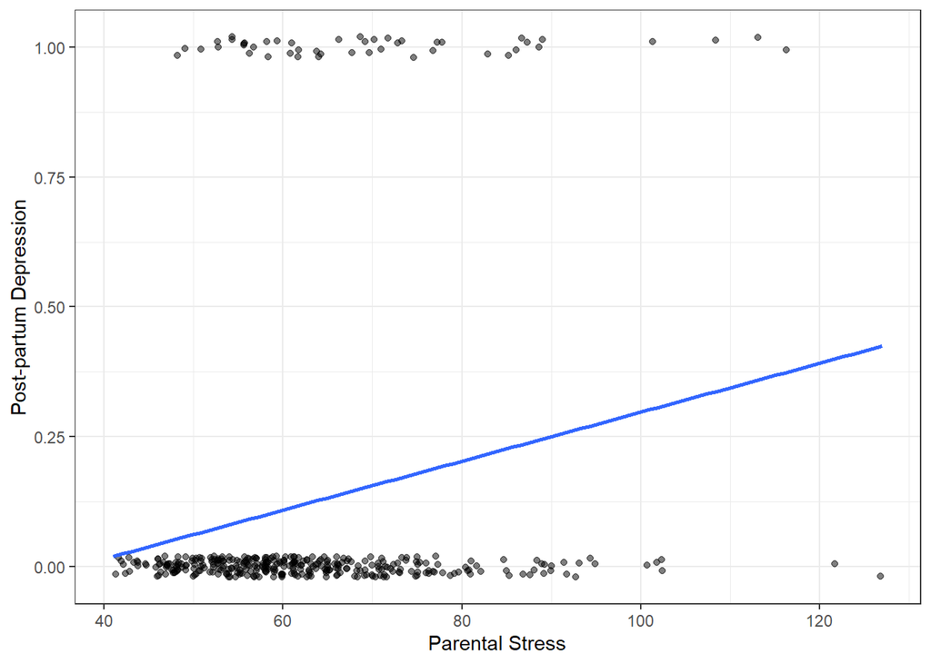

… and check the residuals, pretty bad right?

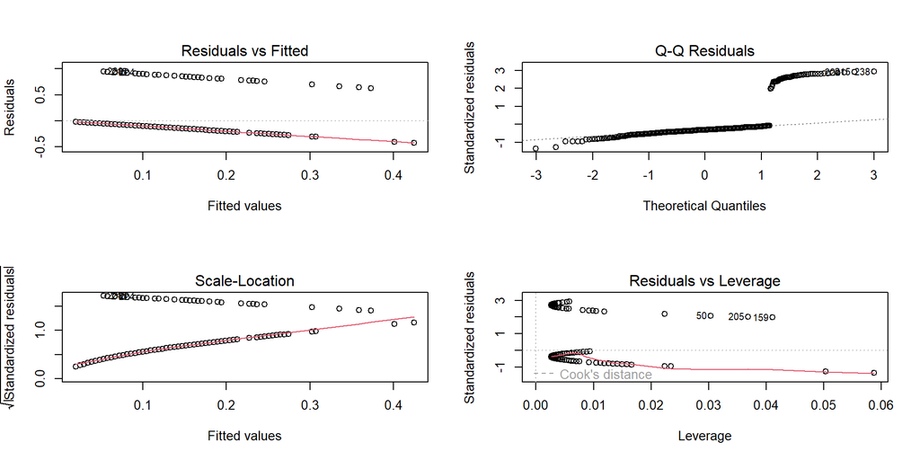

As for the exam example, we could compute a sort of contingency table despite the `Parental_stress` is a numerical variable by creating some discrete categories (just for exploratory analysis):

```r
table(teddy$Depression_pp, teddy$Parental_stress_c) |>
    round(2)
```

```
##
##       < 40 40-60 60-80 80-100 > 100
##   No     0   164   136     26     6
##   Yes    0    15    21      7     4
```

```r
table(teddy$Depression_pp, teddy$Parental_stress_c) |>
    prop.table(margin = 2) |>
    round(2)
```

```
##
##       < 40 40-60 60-80 80-100 > 100
##   No        0.92  0.87   0.79  0.60
##   Yes       0.08  0.13   0.21  0.40
```

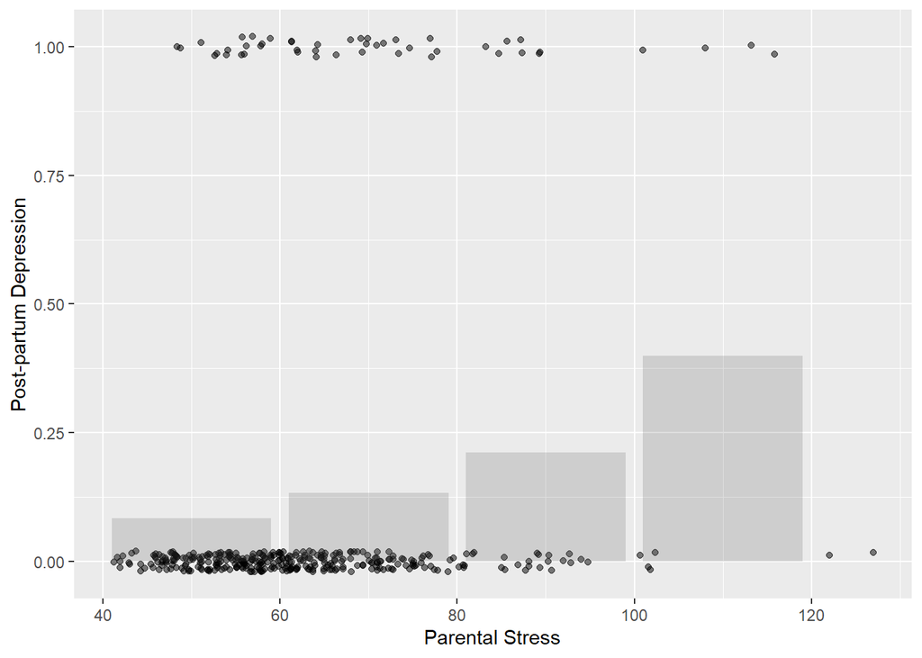

```r
teddy$Parental_stress.=as.numeric(teddy$Parental_stress_c)*20+10
#
tb=table(teddy$Depression_pp, teddy$Parental_stress_c) |>
    prop.table(margin = 2)
 Dc=data.frame(Parental_stress.=sort(unique(teddy$Parental_stress.)),probs=tb[2,-1])

# Plot
teddy_plot +
    geom_bar(data=Dc,aes(x=Parental_stress.,y=probs),stat="identity",alpha=.2)
```

Ideally, we could compute the increase in the odds of having the post-partum depression as the parental stress increase. In fact, as we are going to see, the Binomial GLM is able to estimate the non-linear increase in the probability.

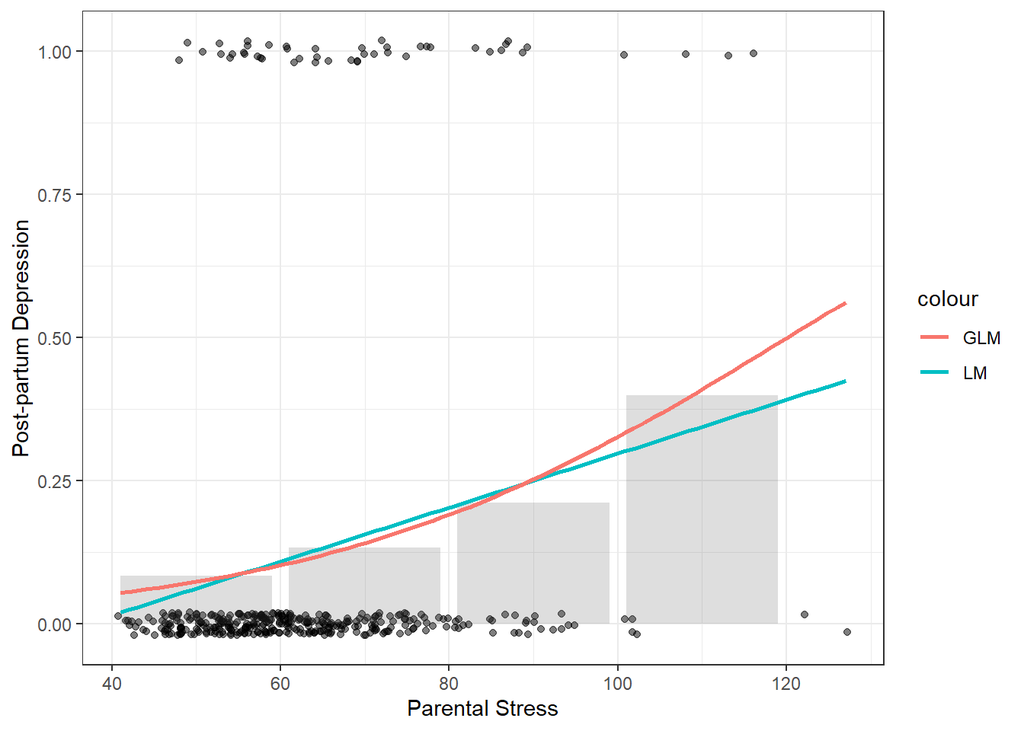

# Binomial GLM

- The **random component** of a Binomial GLM the binomial distribution with parameter $p$
- The **systematic component** is a linear combination of predictors and coefficients $\boldsymbol{\beta X}$
- The **link function** is a function that map probabilities into the $[-\infty, +\infty]$ range.

## Logit Link

The **logit** link is the most common link function when using a binomial GLM:

$$log \left(\frac{p_i}{1 - p_i}\right) = \beta_0 + \beta_1x_{i1} +
\beta_2x_{i2} + \cdots + \beta_px_{ip}$$

The inverse of the **logit** maps again the probability into the $[0, 1]$ range:

$$p = \frac{e^{\beta_0 + \beta_1x_{i1} + \beta_2x_{i2} + \cdots +
\beta_px_{ip}}}{1 + e^{\beta_0 + \beta_1x_{i1} + \beta_2x_{i2} + \cdots
+ \beta_px_{ip}}}$$

Thus with a single numerical predictor $x$ the relationship between $x$ and $p$ in non-linear on the probability scale but linear on the logit scale.

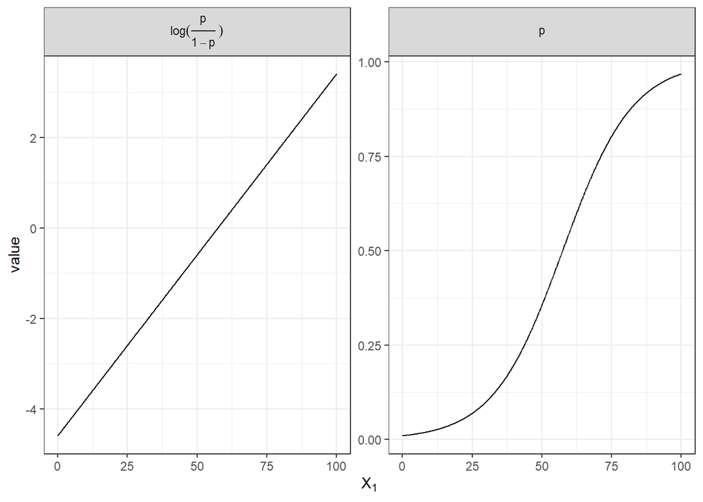

The problem is that effects are non-linear, thus is more difficult to interpret and report model results

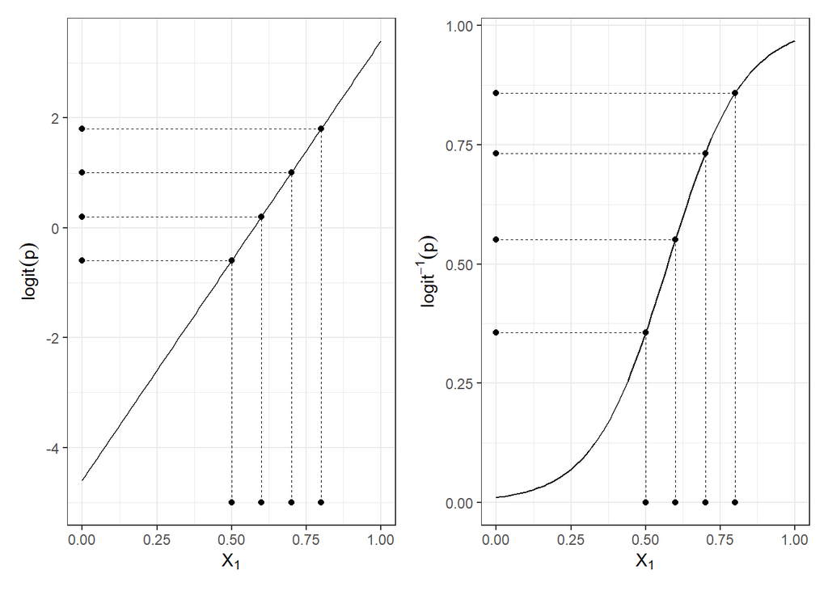

## Model fitting in R

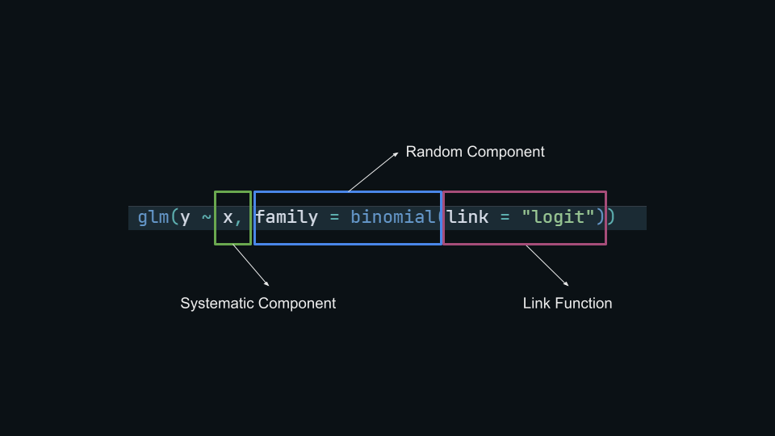

### The big picture…

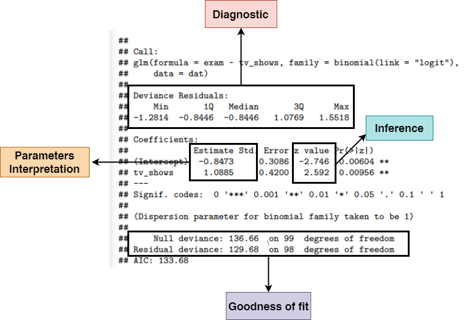

```
##     tv_shows
## exam  0  1
##    0 35 22
##    1 15 28
```

```
##   tv_shows exam
## 1        1    0
## 2        1    1
## 3        1    1
## 4        1    1
## 5      ...  ...
## 6        0    0
## 7        0    1
## 8        0    0
## 9        0    0
```

## Intercept only model

Let’s start from the simplest model (often called null model) where there are no predictors:

```r
fit0 <- glm(exam ~ 1, data = dat, family = binomial(link = "logit"))
summary(fit0)
```

```
##
## Call:
## glm(formula = exam ~ 1, family = binomial(link = "logit"), data = dat)
##
## Coefficients:
##             Estimate Std. Error z value Pr(>|z|)
## (Intercept)  -0.2819     0.2020  -1.395    0.163
##
## (Dispersion parameter for binomial family taken to be 1)
##
##     Null deviance: 136.66  on 99  degrees of freedom
## Residual deviance: 136.66  on 99  degrees of freedom
## AIC: 138.66
##
## Number of Fisher Scoring iterations: 4
```

When fitting an intercept-only model, the parameter is the average value of the `y` variable:

$$\begin{align*}
\log(\frac{p}{1 - p}) = \beta_0 \\
p = \frac{e^{\beta_0}}{1 + e^{\beta_0}}
\end{align*}$$

In R, the $logit(p)$ is computed using `qlogis()` that is the `q` + `logis` combination of functions to work with probability distributions. The $logit^{-1}$ thus the inverse of the logit function is `plogis()`:

```r
# average y on the respo nse scale
mean(dat$exam)
```

```
## [1] 0.43
```

```r
c("logit" = coef(fit0)[1],
  "inv-logit" = plogis(coef(fit0)[1])
)
```

```
##     logit.(Intercept) inv-logit.(Intercept)
##            -0.2818512             0.4300000
```

## Link function (TIPS)

If you are not sure about how to transform using the link function you can directly access the `family()` object in R that contains the appropriate link function and the corresponding inverse.

```r
bin <- binomial(link = "logit")
bin$linkfun() # the same as qlogis
bin$linkinv() # the same as plogis
```

## Model with $X$

Now we can add the `tv_shows` predictor. Now the model has two coefficients. Given that the `tv_shows` is a binary variable, the intercept is the average `y` when `tv_shows` is 0, and the `tv_shows` coefficient is the increase in `y` for a unit increase in `tv_shows`:

```r
fit <- glm(exam ~ tv_shows, data = dat, family = binomial(link = "logit"))
summary(fit)
```

```
##
## Call:
## glm(formula = exam ~ tv_shows, family = binomial(link = "logit"),
##     data = dat)
##
## Coefficients:
##             Estimate Std. Error z value Pr(>|z|)
## (Intercept)  -0.8473     0.3086  -2.746  0.00604 **
## tv_shows      1.0885     0.4200   2.592  0.00956 **
## ---
## Signif. codes:  0 '***' 0.001 '**' 0.01 '*' 0.05 '.' 0.1 ' ' 1
##
## (Dispersion parameter for binomial family taken to be 1)
##
##     Null deviance: 136.66  on 99  degrees of freedom
## Residual deviance: 129.68  on 98  degrees of freedom
## AIC: 133.68
##
## Number of Fisher Scoring iterations: 4
```

Thinking about our data, the `(Intercept)` is the probability of passing the exam without watching tv-shows. The `tv_shows` (should be) the difference in the probability of passing the exam between people who watched or did not watched tv-shows, BUT:

```r
# from model coefficients
exp(coef(fit)["tv_shows"])
```

```
## tv_shows
## 2.969697
```

```r
# from the contingency table
odds_ratio(mean(dat$exam[dat$tv_shows == 1]),
           mean(dat$exam[dat$tv_shows == 0]))
```

```
## [1] 2.969697
```

# Parameter Intepretation

## Model Intepretation

Given the non-linearity and the link function, parameter intepretation is not easy for GLMs. In the case of the Binomial GLM we will see:

- interpreting model coefficients on the linear and logit scale
- odds ratio (already introduced)
- the divide by 4 rule [@Gelman2020-tg; @Gelman2006-pc]
- marginal effects
- predicted probabilities

## `marginaleffects` package

The `marginaleffects` [package](https://marginaleffects.com/) provide a very complete and comprehensive framework to compute marginal effects for several models. You can have a very detailed overview of the theory and the functions reading:

- The main paper by @Arel-Bundock2024-zl
- https://www.youtube.com/watch?v=ANDC_kkAjeM

@Arel-Bundock2024-zl provided an overview about intepreting effects from a fitted model, these are the main elements:

1. **Quantity**: What is the quantity of interest? Do we want to report a prediction or a function of predictions (average, difference, ratio, derivative, etc.)?
   - predictions
   - comparisons (e.g., contrasts)
   - slopes (i.e., derivatives)
2. **Grid**: What predictor values are we interested in? Do we want to report estimates for the units in our dataset, or for hypothetical or representative individuals?
3. **Aggregation**: Do we report estimates for every observation in the grid or a global summary?
4. **Uncertainty**: How do we quantify uncertainty about our estimates?
5. **Test**: Which (non-)linear hypothesis or equivalence tests do we conduct?

We will not see everything, but I strongly suggest you to read the paper and try the package!

## `marginaleffects` vs `emmeans`

`emmeans` is another very popular package for computing “**e**stimated **m**arginal **means**”. They provide similar functionalities but `emmeans` is used more for balanced dataset usually from experimental research (e.g., balanced factorial designs) while `marginaleffects` is used more in observational research using more complex models especially with numerical variables.

## Intepreting model coefficients

Models coefficients are interpreted in the same way as standard regression models. The big difference concerns:

- numerical predictors
- categorical predictors

Using **contrast coding** and **centering/standardizing** we can make model coefficients easier to intepret.

## Categorical predictors

We use a categorical predictor with $p$ levels, the model will estimate $p - 1$ parameters. The interpretation of these parameters is controlled by the contrast coding. In R the default is the treatment coding (or dummy coding). Essentially R create $p - 1$ dummy variables (0 and 1) where 0 is the reference level (usually the first category) and 1 is the current level. We can see the coding scheme using the `model.matrix()` function that return the $\boldsymbol{X}$ matrix:

```
##   X.Intercept. tv_shows
## 1            1        1
## 2            1        1
## 3            1        1
## 4            1        1
## 5          ...      ...
## 6            1        0
## 7            1        0
## 8            1        0
## 9            1        0
```

In the simple case of the `exam` dataset, the intercept ($\beta_0$) is the reference level (default to 0 because is the first) and $\beta_0$ is the difference between the actual level and the reference level. If we change the order of the levels we could change the intercept value while $\beta_1$ will be the same. As an example we could use the so-called sum to zero coding where instead of assigning 0 and 1 we use different values. For example assigning -0.5 and 0.5 will make the intercept the grand-mean:

```r
dat$tv_shows0 <- ifelse(dat$tv_shows == 0, -0.5, 0.5)
fit <- glm(exam ~ tv_shows0, data = dat, family = binomial(link = "logit"))
# grand mean
mean(c(mean(dat$exam[dat$tv_shows == 1]), mean(dat$exam[dat$tv_shows == 0])))
```

```
## [1] 0.43
```

```r
# intercept
plogis(coef(fit)[1])
```

```
## (Intercept)
##   0.4248077
```

## Numerical predictors

With numerical predictors the idea is the same as categorical predictors. In fact, categorical predictors are converted into numbers (i.e., 0 and 1 or -0.5 and 0.5). The only caveat is that the effects are linear only the **logit** scale. Thus $\beta_1$ is interpreted in the same way as standard linear models only on the link-function scale. For the **binomial**

GLM the $\beta_1$ is the increase in the $log(odds(p))$ for a unit-increase in the $x$. In the response (probability) scale, the $\beta_1$ is the multiplicative increase in the odds of $y = 1$ for a unit increase in the predictor.

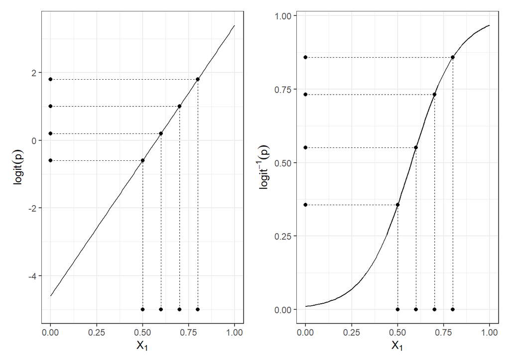

$$x_{cen} = x_i - \hat x$$

$$x_{z} = \frac{x_i - \hat x}{\sigma_x}$$

Let’s return to our teddy child example and fitting the proper model:

```r
fit_glm <- glm(Depression_pp01 ~ Parental_stress, data = teddy, family = binomial(link = "logit"))
summary(fit_glm)
```

```
##
## Call:
## glm(formula = Depression_pp01 ~ Parental_stress, family = binomial(link = "logit"),
##     data = teddy)
##
## Coefficients:
##                  Estimate Std. Error z value Pr(>|z|)
## (Intercept)     -4.323906   0.690689  -6.260 3.84e-10 ***
## Parental_stress  0.036015   0.009838   3.661 0.000251 ***
## ---
## Signif. codes:  0 '***' 0.001 '**' 0.01 '*' 0.05 '.' 0.1 ' ' 1
##
## (Dispersion parameter for binomial family taken to be 1)
##
##     Null deviance: 284.13  on 378  degrees of freedom
## Residual deviance: 271.23  on 377  degrees of freedom
## AIC: 275.23
##
## Number of Fisher Scoring iterations: 5
```

The `(Intercept)` ($\beta_0$) is the probability of having post-partum depression for a mother with parental stress zero (maybe better centering?)

$$p(yes|x = 0) = g^{-1}(\beta_0)$$

```r
plogis(coef(fit_glm)["(Intercept)"])
```

```
## (Intercept)
##  0.01307482
```

The `Parental_stress` ($\beta_1$) is the increase in the $log(odds)$ of having the post-partum depression for a unit increase in the parental stress index. If we take the exponential of $\beta_1$ we obtain the increase in the $odds$ of having post-partum depression for a unit increase in parental stress index.

```r
exp(coef(fit_glm)["Parental_stress"])
```

```
## Parental_stress
##        1.036671
```

The problem is that, as shown before, the effects are non-linear on the probability scale while are linear on the logit scale. On the logit scale, all differences are constant:

```r
pr <- list(c(10, 11), c(50, 51), c(70, 71))

predictions <- lapply(pr, function(x) {
    predict(fit_glm, newdata = data.frame(Parental_stress = x))
})

# notice that the difference is exactly the Parental_stress parameter
sapply(predictions, diff)
```

```
##         2         2         2
## 0.0360147 0.0360147 0.0360147
```

While on the probability scale, the differences are not the same. This is problematic when interpreting the results of a Binomial GLM with a numerical predictor.

```r
(predictions <- lapply(predictions, plogis))
```

```
## [[1]]
##          1          2
## 0.01863764 0.01930790
##
## [[2]]
##          1          2
## 0.07424969 0.07676350
##
## [[3]]
##         1         2
## 0.1415012 0.1459330
```

```r
sapply(predictions, diff)
```

```
##            2            2            2
## 0.0006702661 0.0025138036 0.0044317558
```

## Predicted probabilities

In a similar way we can use the inverse logit function to find the predicted probability specific values of $x$. For example, the difference between $p(y = 1|x = 2.5) - p(y = 1|x = 5)$ can be calculated using the model equation:

- $p(y = 1|x = 2.5) = \frac{e^{\beta_0 + \beta_1 2.5}}{1 + e^{\beta_0 + \beta_1 2.5}}$
- $p(y = 1|x = 5) = \frac{e^{\beta_0 + \beta_1 5}}{1 + e^{\beta_0 + \beta_1 5}}$
- $p(y = 1|x = 5) - p(y = 1|x = 2.5)$
- remember that $logit^{-1}(\beta_0 + \beta_1 X)=\frac{e^{\beta_0 + \beta_1 X}}{1 + e^{\beta_0 + \beta_1 X}}$

```r
coefs <- coef(fit)
plogis(coefs[1] + coefs[2]*5) - plogis(coefs[1] + coefs[2]*2.5)
```

```
##  (Intercept)
## 4.642617e-10
```

In R we can use directly the `predict()` function with the argument `type = "response"` to return the predicted probabilities instead of the logits:

```r
preds <- predict(fit, newdata = list(x = c(2.5, 5)), type = "response")
preds
```

```
## 1 2
## 1 1
```

```r
preds[2] - preds[1]
```

```
##            2
## 4.642615e-10
```

I have written the `epredict()` function that extend the `predict()` function giving some useful messages when computing predictions. you can use it with every model and also with multiple predictors.

```r
epredict(fit, values = list(x = c(2.5, 5)), type = "response")
```

```
## y ~ - 6.91 + 11.36*c(2.5, 5)
```

```
## [1] 1 1
```

## Marginal effects

A marginal effect measures the association between a change in a predictor ($x$), and a change in the response $y$.

The slope can be evaluated for any level of $x$. In fact, the divide-by-4 rule is the maximal slope evaluated at a specific $x$.

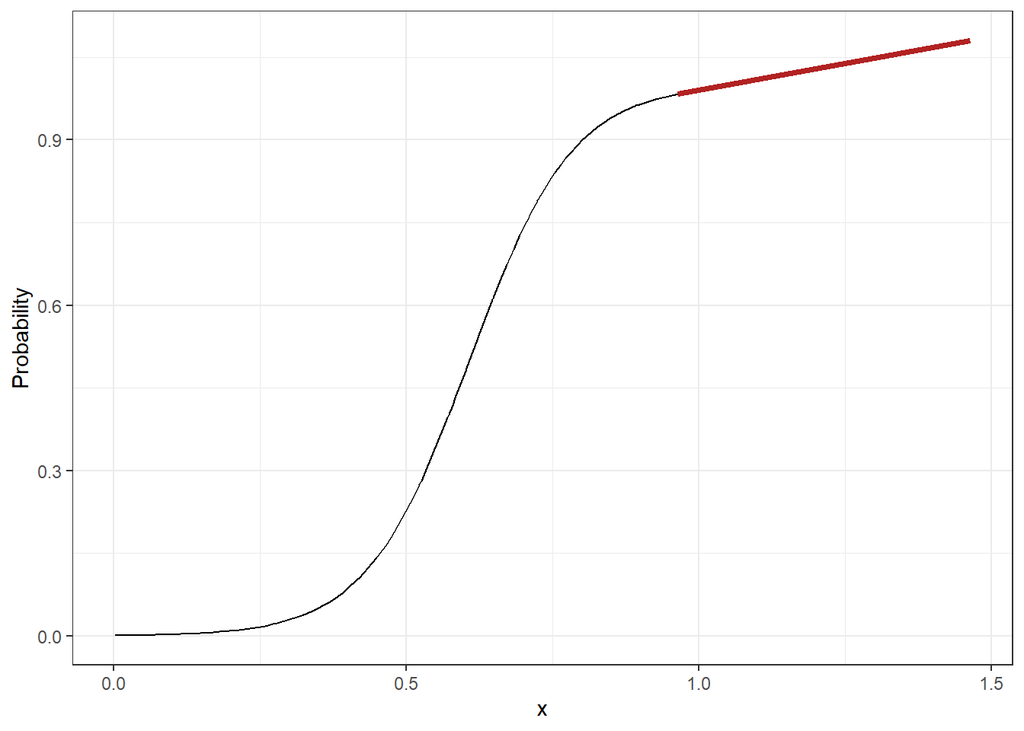

The divide-by-4 rule is the maximal marginal effect. The average marginal effects is the average of all slopes. This can be easily done with the `marginaleffects` package:

```r
library(marginaleffects)

# all marginal effects
slopes(fit)
##
##  Estimate Std. Error     z Pr(>|z|)    S   2.5 % 97.5 %
##    1.8970     0.3614 5.249  < 0.001 22.6  1.1887 2.6053
##    0.0303     0.0330 0.918  0.35857  1.5 -0.0343 0.0949
##    2.2041     0.4176 5.278  < 0.001 22.9  1.3856 3.0227
##    2.3011     0.4014 5.732  < 0.001 26.6  1.5143 3.0879
##    0.0776     0.0693 1.119  0.26293  1.9 -0.0583 0.2135
## --- 90 rows omitted. See ?print.marginaleffects ---
##    0.0187     0.0223 0.842  0.39982  1.3 -0.0249 0.0624
##    0.2091     0.1422 1.471  0.14137  2.8 -0.0696 0.4878
##    0.0130     0.0164 0.792  0.42859  1.2 -0.0191 0.0451
##    2.2424     0.3895 5.758  < 0.001 26.8  1.4791 3.0058
##    0.8147     0.2690 3.028  0.00246  8.7  0.2874 1.3420
## Term: x
## Type: response
## Comparison: dY/dX
```

```r
# marginal effects when x = 5
slopes(fit, newdata = data.frame(x = 2))
```

```
##
##  Estimate Std. Error     z Pr(>|z|)   S     2.5 %   97.5 % x
##  1.55e-06   1.68e-05 0.092    0.927 0.1 -3.14e-05 3.45e-05 2
##
## Term: x
## Type: response
## Comparison: dY/dX
```

```r
# average marginal effect
avg_slopes(fit)
```

```
##
##  Estimate Std. Error    z Pr(>|z|)     S 2.5 % 97.5 %
##      1.19     0.0629 18.9   <0.001 261.6  1.06   1.31
##
## Term: x
## Type: response
## Comparison: dY/dX
```

With multiple variables, marginal effects are also useful to see the effect of one predictor fixing the level of others. Let’s simulate a model with two predictors:

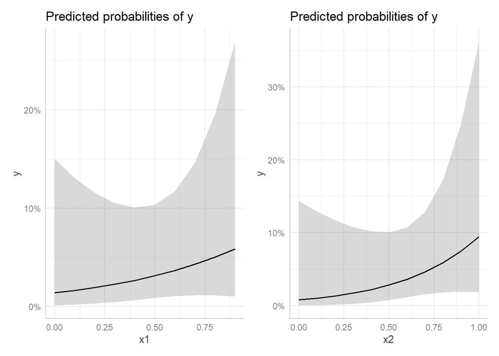

```r
dat <- sim_design(100, nx = list(x1 = runif(100), x2 = runif(100)))
dat <- sim_data(dat, plogis(qlogis(0.001) + 5 * x1 + 2 * x2), model = "binomial")
fit <- glm(y ~ x1 + x2, data = dat, family = binomial(link = "logit"))
plot(ggeffect(fit)$x1) | plot(ggeffect(fit)$x2)
```

We can see the marginal effects (each, average or marginal) for the $x1$ while fixing $x2$ to the mean:

```r
slopes(fit, newdata = data.frame(x1 = dat$x1, x2 = mean(dat$x2)))
```

```
##
##  Term Estimate Std. Error     z Pr(>|z|)   S    2.5 % 97.5 %     x1    x2
##    x1   0.0311     0.0244 1.272    0.203 2.3 -0.01681 0.0790 0.1990 0.508
##    x1   0.0576     0.0791 0.728    0.467 1.1 -0.09745 0.2126 0.5956 0.508
##    x1   0.0368     0.0341 1.079    0.281 1.8 -0.03004 0.1036 0.3061 0.508
##    x1   0.0452     0.0507 0.891    0.373 1.4 -0.05417 0.1445 0.4373 0.508
##    x1   0.0237     0.0151 1.566    0.117 3.1 -0.00596 0.0534 0.0285 0.508
## --- 190 rows omitted. See ?print.marginaleffects ---
##    x2   0.0829     0.0561 1.477    0.140 2.8 -0.02714 0.1929 0.5456 0.508
##    x2   0.0481     0.0465 1.036    0.300 1.7 -0.04295 0.1392 0.1967 0.508
##    x2   0.0489     0.0465 1.052    0.293 1.8 -0.04229 0.1402 0.2074 0.508
##    x2   0.0442     0.0461 0.960    0.337 1.6 -0.04606 0.1346 0.1436 0.508
##    x2   0.0480     0.0465 1.033    0.302 1.7 -0.04305 0.1390 0.1950 0.508
## Type: response
## Comparison: dY/dX
```

## Divide by 4 rule

The **divide by 4 rule** is a very easy way to evaluate the effect of a continuous predictor.

Given the non-linearity, the derivative of the logistic function (i.e., the slope) is maximal for probabilities around ~$0.5$.

In fact, $\beta_i p (1 - p)$ is maximized when $p = 0.5$ turning into $\beta_i 0.25$ (i.e., dividing by 4).

Dividing $\beta/4$ we obtain the maximal slope thus the maximal difference in probability.

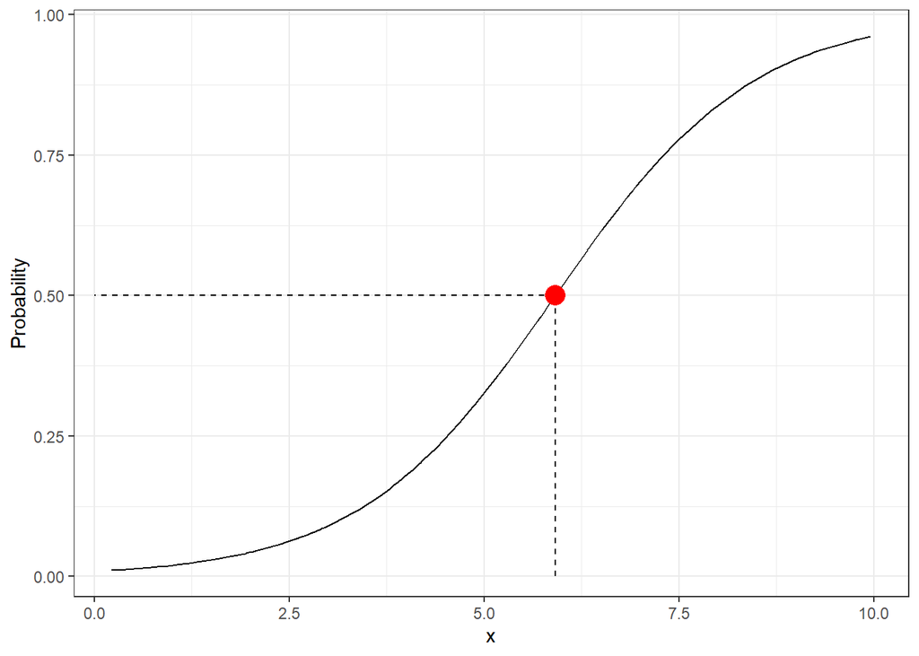

## Misleading divide by 4 rule

The divide by 4 rule can be misleading where at 50% accuracy we have few or no data.

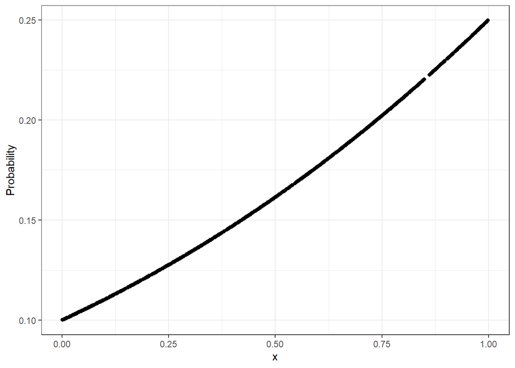

```
##
## Call:  glm(formula = Depression_pp01 ~ Parental_stress, family = binomial(link = "logit"),
##     data = teddy)
##
## Coefficients:
##     (Intercept)  Parental_stress
##        -4.32391          0.03601
##
## Degrees of Freedom: 378 Total (i.e. Null);  377 Residual
## Null Deviance:       284.1
## Residual Deviance: 271.2     AIC: 275.2
```

For example, in the `TeddyChild` dataset, the relationship between post-partum depression and parental stress cover a wide range but there are few observation around $y = 50\%$:

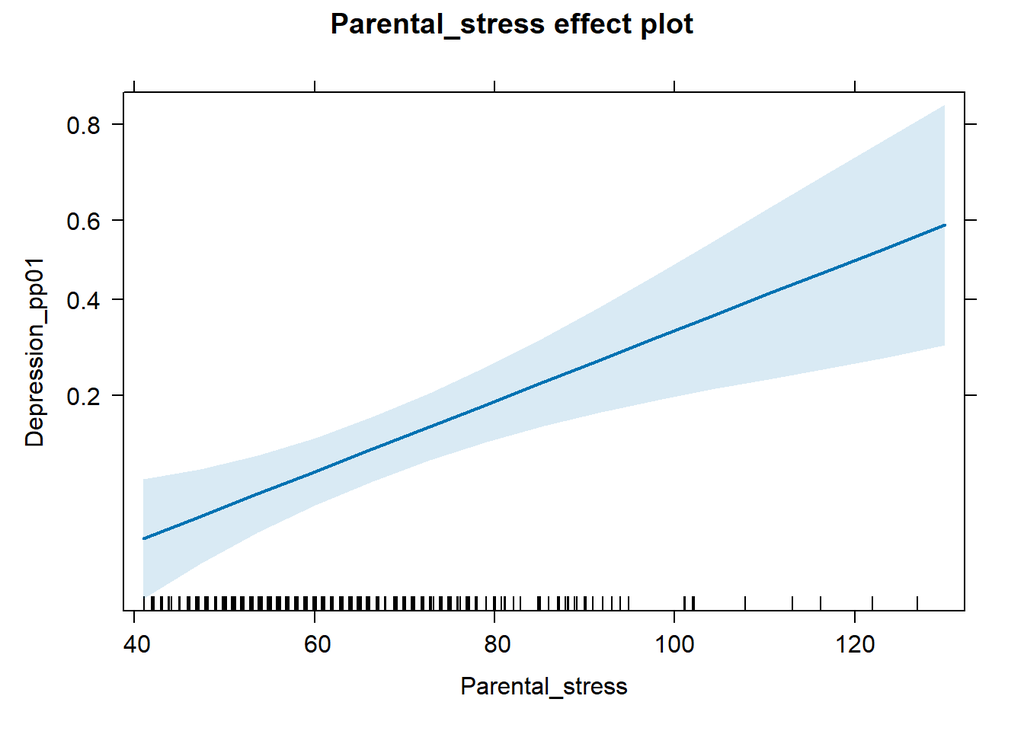

```r
library(effects)
plot(allEffects(fit_glm))
```

## Inverse estimation[^2]

Sometimes it is useful to do what is called **inverse estimation**, thus predicting the $x$ level associated with a certain $y$. In this case the $x$ producing a certain $p$ of response.

Sometimes this is called **median effective dose** when finding the $x$ level producing $50\%$ of correct responses.

We can use the `MASS::dose.p()` function:

```r
MASS::dose.p(fit, p = c(0.25, 0.5, 0.8))
```

```
##               Dose        SE
## p = 0.25: 4.528452 0.4085118
## p = 0.50: 5.914626 0.3593151
## p = 0.80: 7.663782 0.5361676
```

Clearly, the range of the predictor need to be meaningful. Predicting the probability of post partum depression being 0.9 is probably meaningless given the bounded nature of the predictor variable.

Still using the `TeddyChild` dataset, an application could be to estimate the level of parental stress required to have a certain probability of post-partum depression. For example:

```r
MASS::dose.p(fit_glm, p = c(0.5, 0.7, 0.8))
```

```
##              Dose       SE
## p = 0.5: 120.0595 14.80923
## p = 0.7: 143.5859 21.03040
## p = 0.8: 158.5519 25.04193
```

## Inverse estimation and Psychophysics

In Psychophysics it is common to do the inverse estimation to estimate the detection or performance threshold. For example, estimating the $x$ level associated with a certain probability of success e.g. 50%.

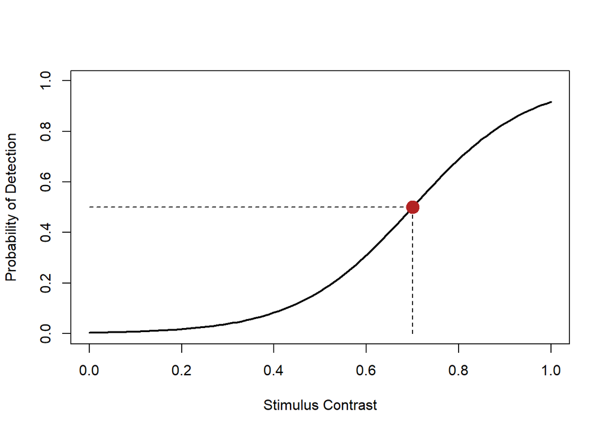

```r
curve(plogis(x, 0.7, 1/8),
      ylim = c(0, 1),
      xlab = "Stimulus Contrast",
      ylab = "Probability of Detection",
      lwd = 2)
segments(x0 = 0.7, y0 = 0, x1 = 0.7, 0.5, lty = 2)
segments(x0 = 0, y0 = 0.5, x1 = 0.7, 0.5, lty = 2)
points(x = 0.7, y = 0.5, pch = 19, col = "firebrick", cex = 2)
```

Let’s simulate and ideal observer that respond to stimuli with different contrast:

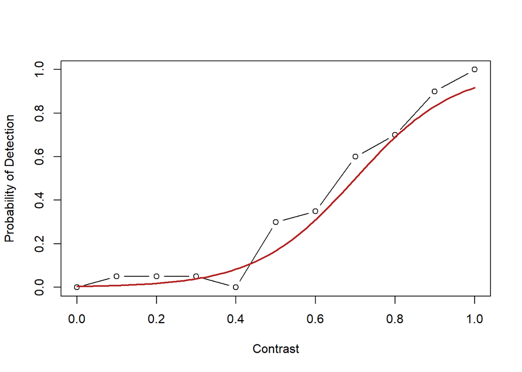

```r
th <- 0.7 # -(b0/b1)
slope <- 1/8

b1 <- 1/slope
b0 <- -th*b1

x <- rep(seq(0, 1, 0.1), each = 20)

p <- plogis(b0 + b1 * x)
y <- rbinom(length(x), 1, p)

yp <- tapply(y, x, mean)
xc <- unique(x)

plot(xc, yp, type = "b", ylim = c(0, 1), xlab = "Contrast", ylab = "Probability of Detection")
curve(plogis(x, th, slope), add = TRUE, col = "firebrick", lwd = 2)
```

```r
fit <- glm(y ~ x, family = binomial(link = "logit"))
summary(fit)
```

```
##
## Call:
## glm(formula = y ~ x, family = binomial(link = "logit"))
##
## Coefficients:
##             Estimate Std. Error z value Pr(>|z|)
## (Intercept)  -5.3907     0.7156  -7.533 4.95e-14 ***
## x             8.2416     1.0754   7.664 1.81e-14 ***
## ---
## Signif. codes:  0 '***' 0.001 '**' 0.01 '*' 0.05 '.' 0.1 ' ' 1
##
## (Dispersion parameter for binomial family taken to be 1)
##
##     Null deviance: 288.41  on 219  degrees of freedom
## Residual deviance: 149.08  on 218  degrees of freedom
## AIC: 153.08
##
## Number of Fisher Scoring iterations: 6
```

```r
-(coef(fit)[1]/coef(fit)[2]) # threshold
```

```
## (Intercept)
##   0.6540815
```

```r
MASS::dose.p(fit, p = 0.5) # with inverse estimation
```

```
##               Dose        SE
## p = 0.5: 0.6540815 0.0252232
```

## Odds Ratio (OR) to Cohen’s $d$

The Odds Ratio can be considered an effect size measure. We can transform the OR into other effect size measure [@Sanchez-Meca2003-ji; @Borenstein2009-mo].

$$d = \log(OR) \frac{\sqrt{3}}{\pi}$$

```r
# in R with the effectsize package
or <- 1.5
effectsize::logoddsratio_to_d(log(or))
```

```
## [1] 0.2235446
```

```r
# or
effectsize::oddsratio_to_d(or)
```

```
## [1] 0.2235446
```

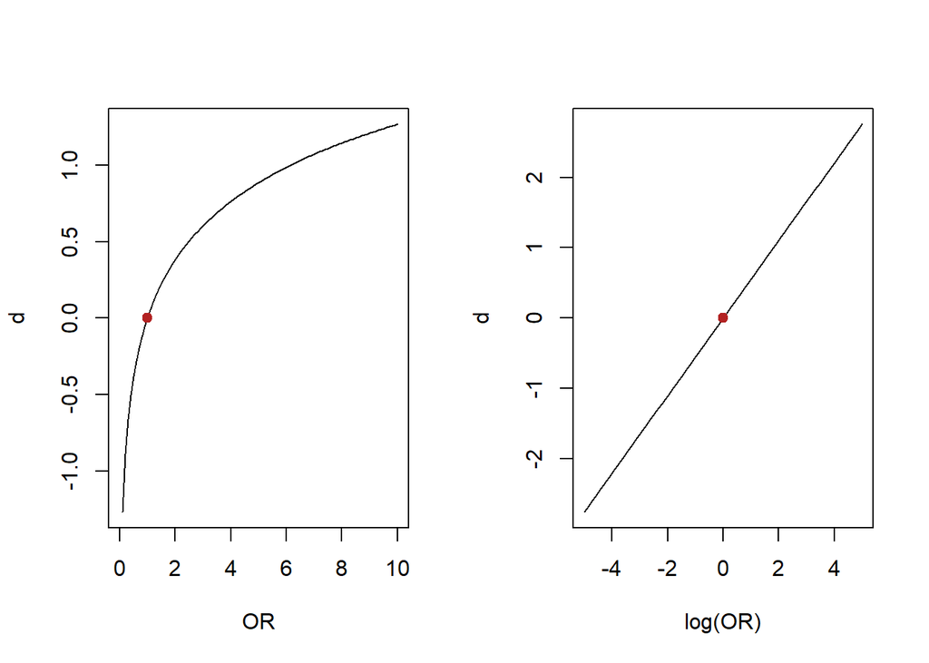

# Inference

## Wald tests

The basic approach when doing inference with GLM is interpreting the Wald test of each model coefficients. The Wald test is calculated as follows:

$$z = \frac{\beta_p - \beta_0}{\sigma_{\beta_p}}$$

Where $\beta$ is the regression coefficients, $\beta_0$ is the value under the null hypothesis (generally 0) and $\sigma_{\beta_p}$ is the standard error. P-values and confidence intervals can be calculated based on a standard normal distribution.

## Wald-type confidence intervals

Wald-type confidence interval (directly from model summary), where $\Phi$ is the cumulative Gaussian function `qnorm()`:

$$95\%CI = \hat \beta \pm \Phi(\alpha/2) SE_{\beta}$$

```r
(summ <- data.frame(summary(fit)$coefficients))
```

```
##               Estimate Std..Error   z.value     Pr...z..
## (Intercept) -0.8472979  0.3086066 -2.745560 0.0060407685
## tv_shows     1.6945957  0.4364356  3.882808 0.0001032569
```

```r
# 95% confidence interval
summ$Estimate + qnorm(c(0.025, 0.95))*summ$Std..Error
```

```
## [1] -1.452156  2.412468
```

## Profile likelihood confidence intervals

The computation is a little bit different and they are not always symmetric:

```r
# profile likelihood, different from wald type
confint(fit)
```

```
##                  2.5 %     97.5 %
## (Intercept) -1.4816321 -0.2621918
## tv_shows     0.8602793  2.5779631
```

You can use the `plot_param()` function (quite overkilled):

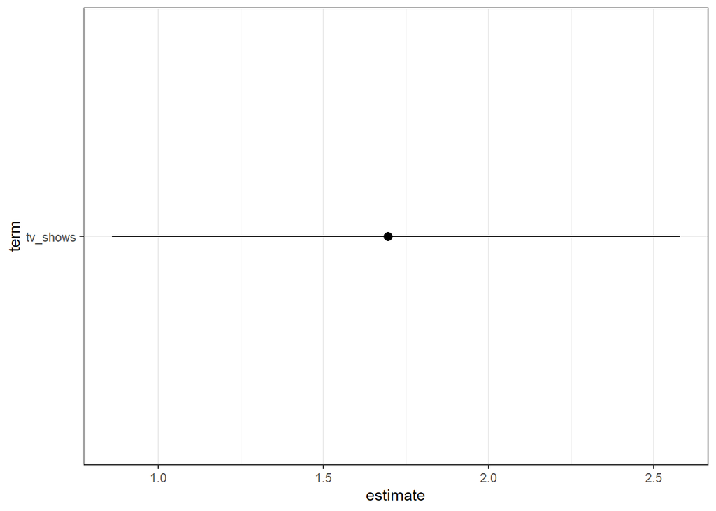

```r
plot_param(fit, "tv_shows")+theme_bw()
```

## Confidence intervals

When calculating confidence intervals it is important to consider the link function. In the same way as we compute the inverse logit function on the parameter value, we could revert also the confidence intervals. **IMPORTANT, do not apply the inverse logit on the standard error and then compute the confidence interval**.

```r
fits <- broom::tidy(fit) # extract parameters as dataframe
fits
```

```
## # A tibble: 2 × 5
##   term        estimate std.error statistic p.value
##   <chr>          <dbl>     <dbl>     <dbl>   <dbl>
## 1 (Intercept)   -0.490     0.291     -1.68 0.0929
## 2 tv_shows       1.15      0.417      2.76 0.00572
```

**NOTE**: Notice that I use `2*se` instead of the precise quantile of the Gaussian distribution that for $\alpha = 0.05$ is $\sim 1.96$

```r
b <- fits$estimate[2]
se <- fits$std.error[2]

# correct, wald-type confidence intervals
c(b = exp(b), lower = exp(b - 2*se), upper = exp(b + 2*se))
```

```
##        b    lower    upper
## 3.167183 1.375115 7.294695
```

```r
# correct, likelihood based confidence intervals
exp(confint(fit, "tv_shows"))
```

```
##    2.5 %   97.5 %
## 1.416352 7.309771
```

```r
# wrong wald type
c(b = exp(b), lower = exp(b) - 2*exp(se), upper = exp(b) + 2*exp(se))
```

```
##         b     lower     upper
## 3.1671827 0.1319149 6.2024504
```

The same principle holds for predicted probabilities. First compute the intervals on the logit scale and then transform-back on the probability scale:

```r
fits <- dat |>
    select(tv_shows) |>
    distinct() |>
    add_predict(fit, se.fit = TRUE)

fits$p <- plogis(fits$fit)
fits$lower <- plogis(with(fits, fit - 2*se.fit))
fits$upper <- plogis(with(fits, fit + 2*se.fit))

fits
```

```
## # A tibble: 2 × 7
##   tv_shows    fit se.fit residual.scale     p lower upper
##      <dbl>  <dbl>  <dbl>          <dbl> <dbl> <dbl> <dbl>
## 1        1  0.663  0.299              1 0.660 0.517 0.779
## 2        0 -0.490  0.291              1 0.380 0.255 0.523
```

## Anova

With multiple predictors, especially with categorical variables with more than 2 levels, we can compute the an anova-like analysis individuating the effect of each predictor. In R we can do this using the `car::Anova()` function. Let’s simulate a model with a 2x2 interaction:

```
##   id x1 x2 y
## 1  1  a  c 1
## 2  2  a  d 1
## 3  3  b  c 0
## 4  4  b  d 1
## 5  5  a  c 1
## 6  6  a  d 0
```

We can fit the most complex model containing the two main effects and the interaction. I set the contrasts for the two factors as `contr.sum()/2` that are required for a proper analysis of factorial designs:

```r
fit_max <- glm(y ~ x1 + x2 + x1:x2, data = dat, family = binomial(link = "logit")) # same as x1 * x2
summary(fit_max)
```

```
##
## Call:
## glm(formula = y ~ x1 + x2 + x1:x2, family = binomial(link = "logit"),
##     data = dat)
##
## Coefficients:
##             Estimate Std. Error z value Pr(>|z|)
## (Intercept)  -0.9772     0.2189  -4.463 8.06e-06 ***
## x11           0.7648     0.4379   1.747   0.0807 .
## x21           1.1070     0.4379   2.528   0.0115 *
## x11:x21       0.1651     0.8757   0.189   0.8505
## ---
## Signif. codes:  0 '***' 0.001 '**' 0.01 '*' 0.05 '.' 0.1 ' ' 1
##
## (Dispersion parameter for binomial family taken to be 1)
##
##     Null deviance: 144.87  on 119  degrees of freedom
## Residual deviance: 134.40  on 116  degrees of freedom
## AIC: 142.4
##
## Number of Fisher Scoring iterations: 4
```

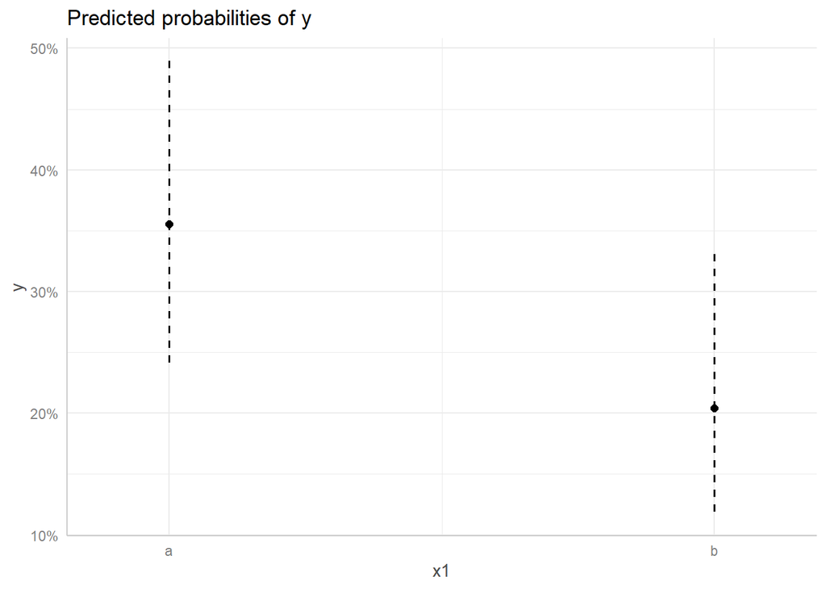

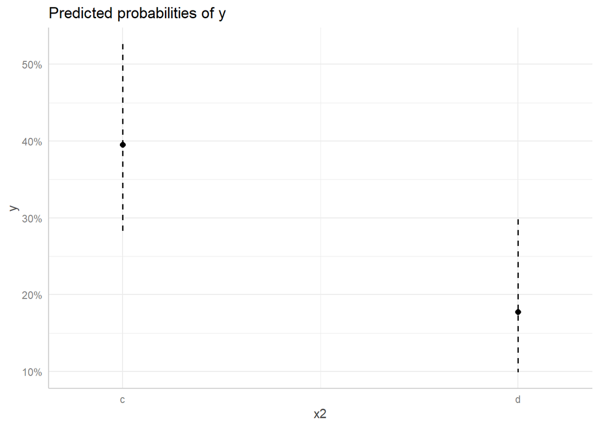

```r
plot(ggeffect(fit_max))
```

Then using `car::Anova()`. For each effect we have the $\chi^2$ statistics and the associated p-value. The null hypothesis is that the specific factor did not contribute in reducing the residual deviance.

```r
car::Anova(fit_max)
```

```
## Analysis of Deviance Table (Type II tests)
##
## Response: y
##       LR Chisq Df Pr(>Chisq)
## x1      3.4977  1   0.061454 .
## x2      7.1448  1   0.007518 **
## x1:x2   0.0354  1   0.850715
## ---
## Signif. codes:  0 '***' 0.001 '**' 0.01 '*' 0.05 '.' 0.1 ' ' 1
```

## Model comparison

The table obtained with `car::Anova()` is essentially a model comparison using the Likelihood Ratio test. This can be done using the `anova(...)` function.

$$\begin{align*}
D = 2 (log(\mathcal{L}_{full}) - log(\mathcal{L}_{reduced})) \\
D \sim \chi^2_{df_{full} - df_{reduced}}
\end{align*}$$

To better understanding, the `x2` effect reported in the `car::Anova()` table is a model comparison between a model with `y ~ x1 + x2` and a model without `x2`. The difference between these two model is the unique contribution of `x2` after controlling for `x1`:

```r
fit <- glm(y ~ x1 + x2, data = dat, family = binomial(link = "logit"))
fit0 <- glm(y ~ x1, data = dat, family = binomial(link = "logit"))

anova(fit0, fit, test = "LRT") # ~ same as car::Anova(fit_max)
```

```
## Analysis of Deviance Table
##
## Model 1: y ~ x1
## Model 2: y ~ x1 + x2
##   Resid. Df Resid. Dev Df Deviance Pr(>Chi)
## 1       118     141.58
## 2       117     134.43  1   7.1448 0.007518 **
## ---
## Signif. codes:  0 '***' 0.001 '**' 0.01 '*' 0.05 '.' 0.1 ' ' 1
```

The model comparison using `anova()` (i.e., likelihood ratio tests) is limited to nested models thus models that differs only for one term. For example:

```r
fit1 <- glm(y ~ x1, data = dat, family = binomial(link = "logit"))
fit2 <- glm(y ~ x2, data = dat, family = binomial(link = "logit"))
fit3 <- glm(y ~ x1 + x2, data = dat, family = binomial(link = "logit"))
```

`fit1` and `fit2` are non-nested because we have the same number of predictors (thus degrees of freedom). `fit3` and `fit1`/`fit2` are nested because `fit3` is more complex and removing one term we can obtain the less complex models.

```r
anova(fit1, fit2, test = "LRT") # do not works properly
```

```
## Analysis of Deviance Table
##
## Model 1: y ~ x1
## Model 2: y ~ x2
##   Resid. Df Resid. Dev Df Deviance Pr(>Chi)
## 1       118     141.58
## 2       118     137.93  0   3.6471
```

```r
anova(fit1, fit3, test = "LRT") # same anova(fit2, fit3)
```

```
## Analysis of Deviance Table
##
## Model 1: y ~ x1
## Model 2: y ~ x1 + x2
##   Resid. Df Resid. Dev Df Deviance Pr(>Chi)
## 1       118     141.58
## 2       117     134.43  1   7.1448 0.007518 **
## ---
## Signif. codes:  0 '***' 0.001 '**' 0.01 '*' 0.05 '.' 0.1 ' ' 1
```

## Information Criteria

As for standard linear models I can use the Akaike Information Criteria (AIC) or the Bayesian Information Criteria (BIC) to compare non-nested models. The downside is not having a properly hypothesis testing setup.

```r
data.frame(BIC(fit1, fit2, fit3)) |>
    arrange(BIC)
```

```
##      df      BIC
## fit2  2 147.5056
## fit3  3 148.7954
## fit1  2 151.1527
```

```r
data.frame(AIC(fit1, fit2, fit3)) |>
    arrange(AIC)
```

```
##      df      AIC
## fit3  3 140.4329
## fit2  2 141.9307
## fit1  2 145.5777
```

## Marginal Means

For post-hoc contrasts you can use the `emmeans` package both for numerical but especially categorical predictors. Let’s simulate a 2x2 interaction:

```r
dat <- sim_design(100, cx = list(x1 = c("a", "b"), x2 = c("c", "d")), contrasts = contr.sum2)
dat <- sim_data(dat, plogis(qlogis(0.25) + 0 * x1_c + 2 * x2_c + 2 * x1_c * x2_c))
fit <- glm(y ~ x1 * x2, data = dat, family = binomial(link = "logit"))
summary(fit)
```

```
##
## Call:
## glm(formula = y ~ x1 * x2, family = binomial(link = "logit"),
##     data = dat)
##
## Coefficients:
##             Estimate Std. Error z value Pr(>|z|)
## (Intercept)  -1.2836     0.1776  -7.226 4.97e-13 ***
## x11          -0.3336     0.3553  -0.939    0.348
## x21           2.5672     0.3553   7.226 4.97e-13 ***
## x11:x21       2.9686     0.7105   4.178 2.94e-05 ***
## ---
## Signif. codes:  0 '***' 0.001 '**' 0.01 '*' 0.05 '.' 0.1 ' ' 1
##
## (Dispersion parameter for binomial family taken to be 1)
##
##     Null deviance: 486.98  on 399  degrees of freedom
## Residual deviance: 376.25  on 396  degrees of freedom
## AIC: 384.25
##
## Number of Fisher Scoring iterations: 6
```

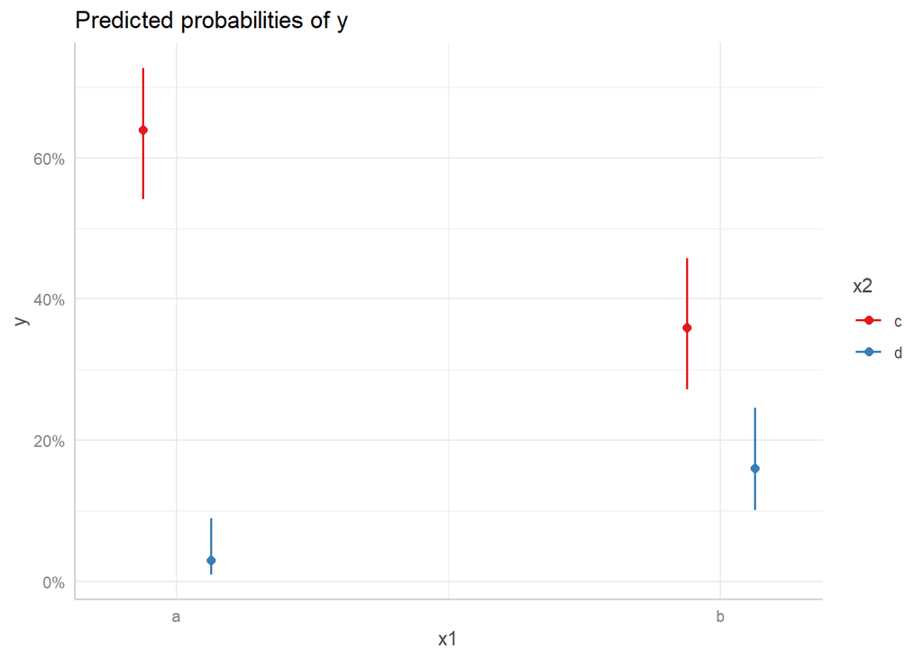

```r
plot(ggeffects::ggeffect(fit, terms = c("x1", "x2")))
```

`emmeans` is a very powerful and complicate package ([documentation](https://cran.r-project.org/web/packages/emmeans/index.html)). Firstly we can estimate the marginal means of the conditions:

```r
library(emmeans)
emmeans(fit, ~ x1 + x2)
```

```
##  x1 x2 emmean    SE  df asymp.LCL asymp.UCL
##  a  c   0.575 0.208 Inf     0.167     0.984
##  b  c  -0.575 0.208 Inf    -0.984    -0.167
##  a  d  -3.476 0.586 Inf    -4.625    -2.327
##  b  d  -1.658 0.273 Inf    -2.193    -1.124
##
## Results are given on the logit (not the response) scale.
## Confidence level used: 0.95
```

We can also calculate the marginal means on the response scale:

```r
library(emmeans)
emmeans(fit, ~ x1 + x2, type = "response")
```

```
##  x1 x2 prob     SE  df asymp.LCL asymp.UCL
##  a  c  0.64 0.0480 Inf   0.54166    0.7278
##  b  c  0.36 0.0480 Inf   0.27216    0.4583
##  a  d  0.03 0.0171 Inf   0.00971    0.0889
##  b  d  0.16 0.0367 Inf   0.10039    0.2453
##
## Confidence level used: 0.95
## Intervals are back-transformed from the logit scale
```

Crucially we can compute the contrasts (i.e., the post-hoc tests). Notice that they are computed on the link-function scale:

```r
emmeans(fit, pairwise ~ x1 | x2)$contrasts
## x2 = c:
##  contrast estimate    SE  df z.ratio p.value
##  a - b        1.15 0.295 Inf   3.906  0.0001
##
## x2 = d:
##  contrast estimate    SE  df z.ratio p.value
##  a - b       -1.82 0.647 Inf  -2.812  0.0049
##
## Results are given on the log odds ratio (not the response) scale.
emmeans(fit, pairwise ~ x1 | x2, type = "response")$contrasts
## x2 = c:
##  contrast odds.ratio    SE  df null z.ratio p.value
##  a / b         3.160 0.931 Inf    1   3.906  0.0001
##
## x2 = d:
##  contrast odds.ratio    SE  df null z.ratio p.value
##  a / b         0.162 0.105 Inf    1  -2.812  0.0049
##
## Tests are performed on the log odds ratio scale
```

Notice the order of the terms to change the actual type of contrasts:

```r
emmeans(fit, pairwise ~ x2 | x1)$contrasts
## x1 = a:
##  contrast estimate    SE  df z.ratio p.value
##  c - d        4.05 0.622 Inf   6.512  <.0001
##
## x1 = b:
##  contrast estimate    SE  df z.ratio p.value
##  c - d        1.08 0.343 Inf   3.155  0.0016
##
## Results are given on the log odds ratio (not the response) scale.
emmeans(fit, pairwise ~ x2 | x1, type = "response")$contrasts
## x1 = a:
##  contrast odds.ratio    SE  df null z.ratio p.value
##  c / d         57.48 35.80 Inf    1   6.512  <.0001
##
## x1 = b:
##  contrast odds.ratio    SE  df null z.ratio p.value
##  c / d          2.95  1.01 Inf    1   3.155  0.0016
##
## Tests are performed on the log odds ratio scale
```

# Plotting effects

When plotting a binomial GLM the most useful way is plotting the marginal probabilities and standard errors/confidence intervals for a given combination of predictors. Let’s make an example for:

- simple GLM with 1 categorical/numerical predictor
- GLM with 2 numerical/categorical predictors
- GLM with interaction between numerical and categorical predictors

A general workflow could be:

- fit the model
- use the `marginaleffects` package or the `predict()` function
- calculating the confidence intervals
- plotting the results

Everything can be simplified using some packages to perform each step and returning a plot:

- `allEffects()` from the `effects()` package (return a base R plot)
- `ggeffect()` from the `ggeffect()` package (return a `ggplot2` object)
- `plot_model` from the `sjPlot` package (similar to `ggeffect()`)

## 1 categorical predictor

In this situation we can just plot the marginal probabilities for each level of the categorical predictor. Plotting our exam dataset:

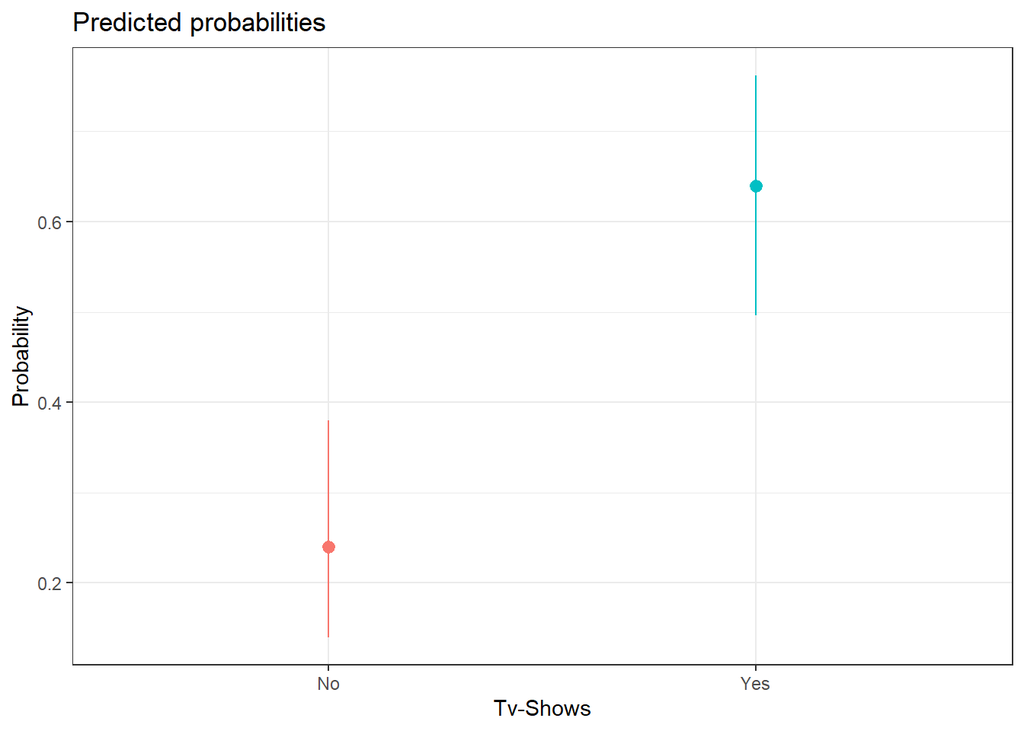

## 1 numerical predictor

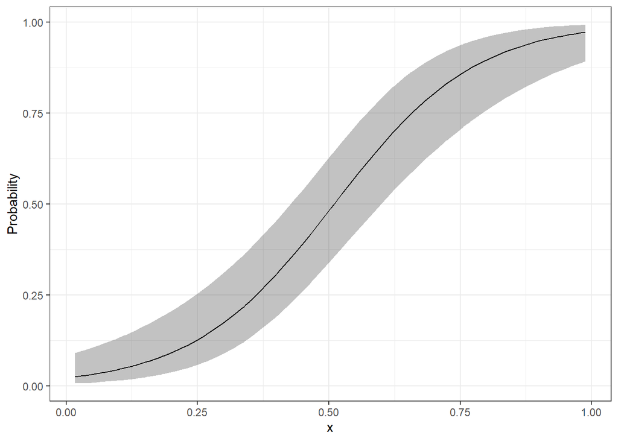

## `allEffects()`

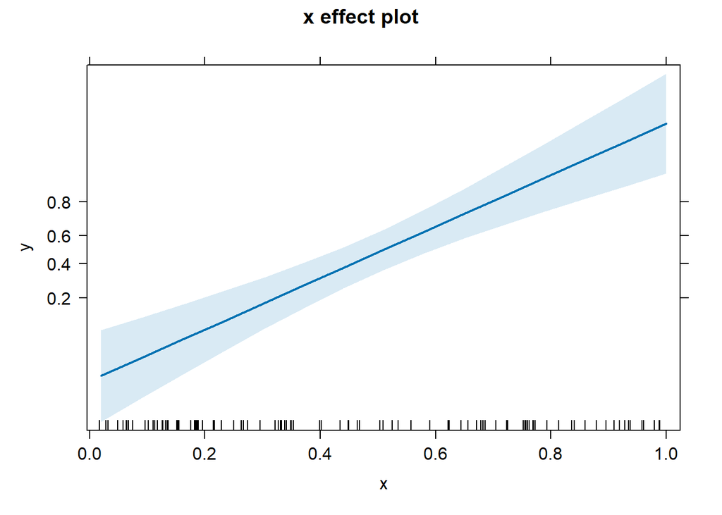

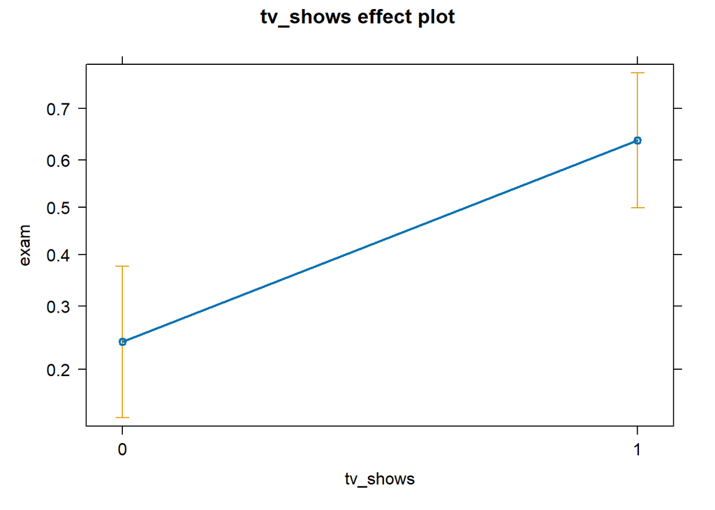

## `ggeffect()`/`plot_model()`

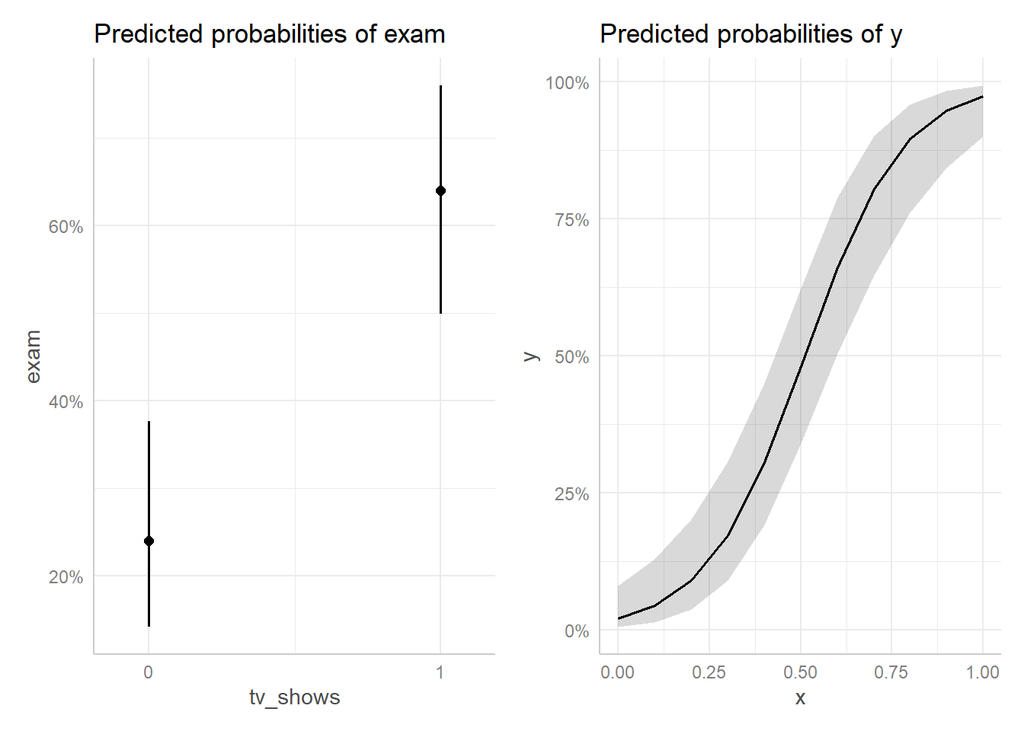

## Plotting coefficients

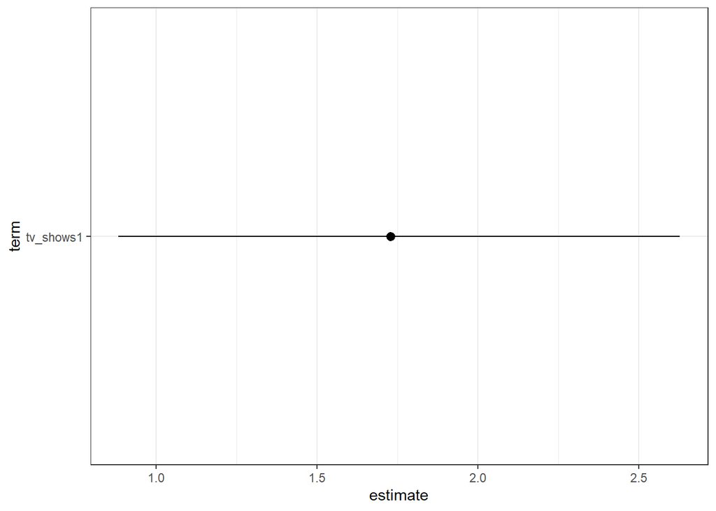

# GLM - Diagnostic

## GLM - Diagnostic

The diagnostic for GLM is similar to standard linear models. Some areas are more complicated for example residual analysis and goodness of fit. We will see:

- Deviance
- $R^2$
- Residuals
  - Types of residuals
  - Residual deviance
- Outliers and influential observations

## Likelihood

The likelihood is the joint probability of the observed data viewed as a function of the parameters.

$$\log \mathcal{L}(\mu|x) = \sum^n_{i = 1} \log(f(x_i;\mu))$$

```r
x <- rnorm(10) # data from normal distribution

# data
x
##  [1]  0.24489318  0.44802136  1.22864696  0.31256683  1.66088715  0.74832530
##  [7] -1.26336813  0.03182055  0.06549473  0.92536938

# the model is a normal distribution with mu = 0 and sd = 1
dnorm(x, 0, 1)
##  [1] 0.3871570 0.3608474 0.1875471 0.3799227 0.1004383 0.3015155 0.1796063
##  [8] 0.3987404 0.3980876 0.2599950

# log likelihood
sum(log(dnorm(x, 0, 1)))
## [1] -13.01149
```

By summing the logarithm all the red segments we obtain the log likelihood of the model given the observed data.

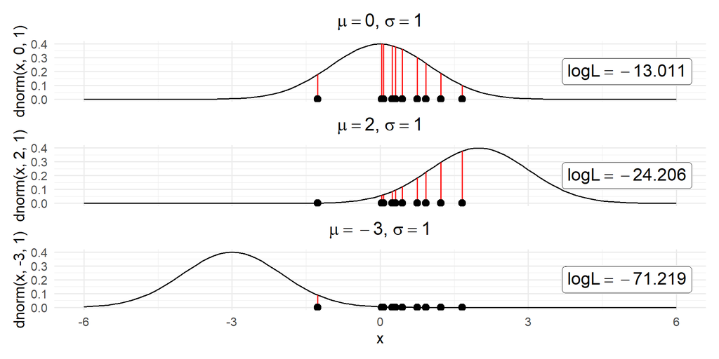

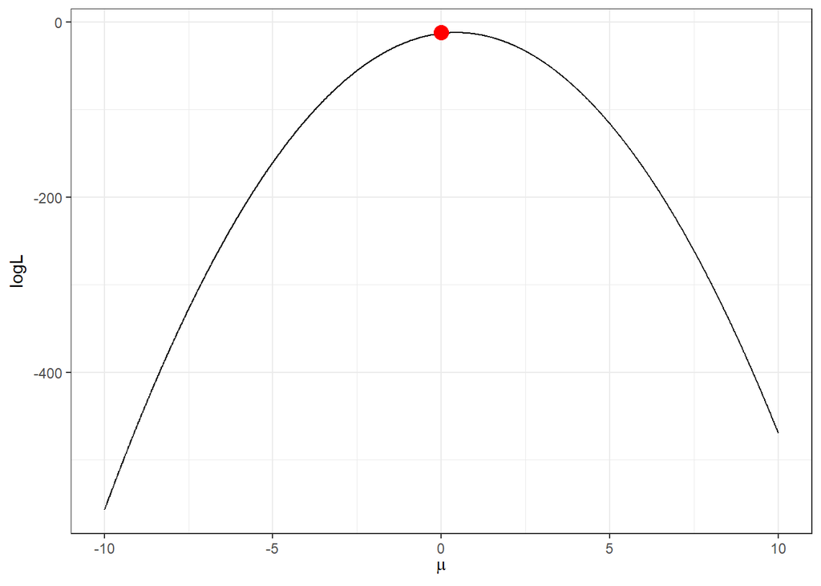